# TSP Energy Supply Modeling

The electric energy market in New York include energy and ancillaries with the primary market by volumn and value being the Locational Based Marginal Price (LBMP) Hourly Day Ahead market. Other markets are the Spot, Installed Capacity (ICAP) and Congestion.

Electric market participants are in wholesale electric markets to manage risk of short term price spikes. Figures 1 and 2 below show the hourly LBMP going back to 2009 and a focus on the last few months. The blue line is a linear model to show the overall trend direction, which has been decreasing for the last decade. In 2020 we see the trend changing with more upward volatility as Figure 2 shows better. For reference the 2014 polar vortex induced price spike can be see in Figure 1.

Winter and summer peaks can be seen in Figure 3 which shows the average monthly prie per MWH. Also as expected the lowest average montly costs is during the swing seasons spring and fall.

Figure 1 Plot of hourly day ahead LBMP over time. The blue line shows a linear model and is used to show the general trend over the past decade. However the last 18 months has seen an increase. If this is lasting is yet to be seen.

Figure 2 This plot show the most reasent few months hourly day ahead LBMP plot. Demonstrating that the declining market has changed direction.

Figure 3 This plot show the average cost per month and show us where the highest and lowest priced months are for informing when to exercise energy efficiency exercises or when to puchase fixed price blocks.

Figure 4 The box chart show more accurately the pricing distribution each month, interesting to see that the 2014 polar vortex did not effect the mean pricing that much.

Figure 8 This chart show the horuly day ahead pricing superimposed with the hourly consumption data from 520 Madison with its electric cooling plant and ice storage system.

Figure 9 The most important chart in the set, this bar chart show a comparison of the 3 strategies under consideration fixed, 50/50 which meand 50% of each day’s consumption will be purchased on the variable index - the LBMP, the remaining 50% off a fixed cost block contract, and finaly a full variable or index contract. We see that the lowest cost strategy is the variable and the highest cost is the full fixed contract.

Figure 10 This chart shows the annual performance of the three strategies for 2023.

Figure 11 This chart show the effect on annual performance of the three strategies given a 2014 like polar vortex.

Figure 12 This chart show the effect on annual performance of the three strategies given a recession induced declining energy market.

Table 1 Comparision of the projected spend for 2023 compaired to a year with a 2014 like polar vortex, or a 2009 like recession.

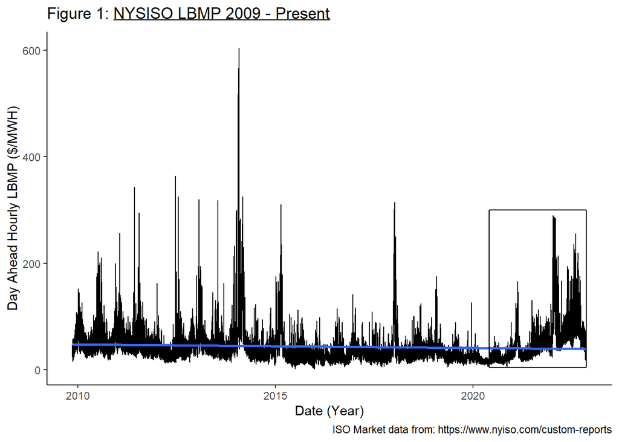

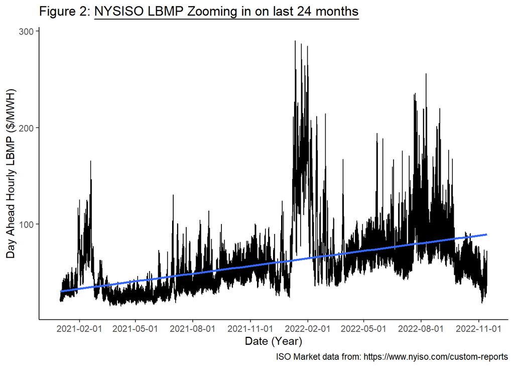

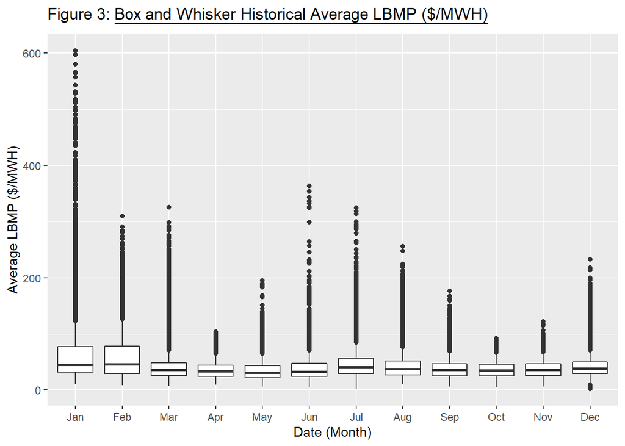

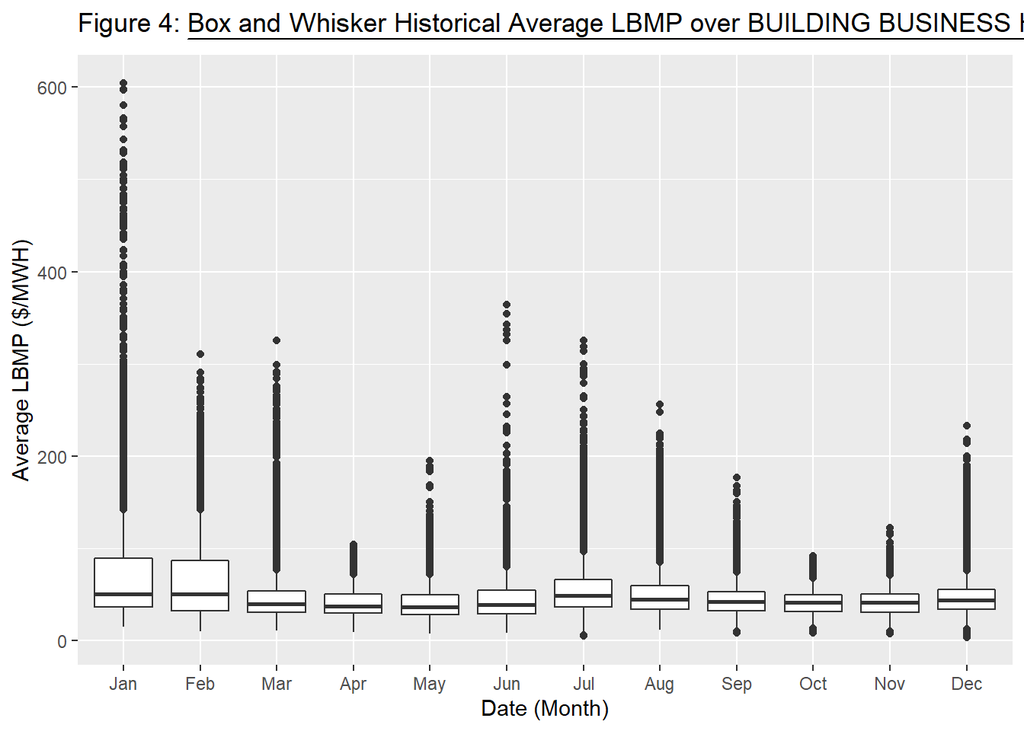

[figure not shown]

[figure not shown]

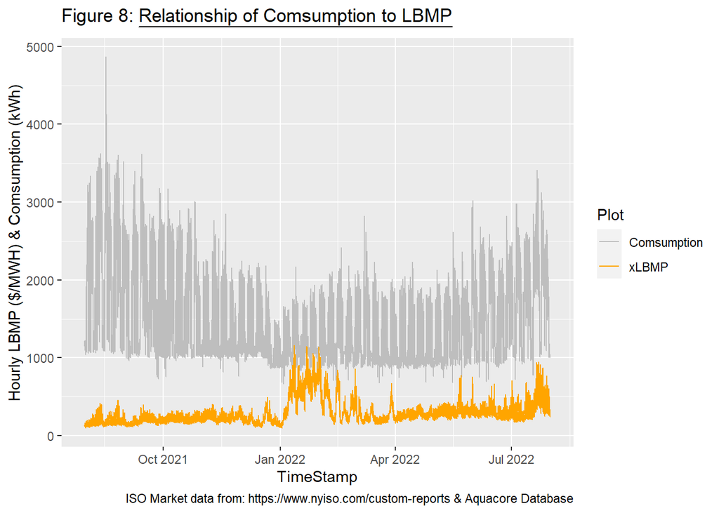

Sensitivity with a polar vortex similar to the 2014 spike.

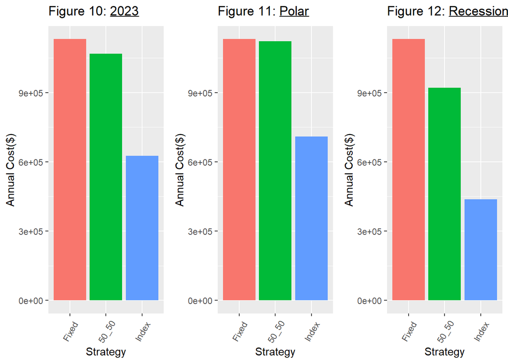

Table 1: Spend under various scenarios

| Strategy | 2023 | Polar | Recession |
| --- | --- | --- | --- |
| Index | 625538 | 708831 | 437877 |
| 50_50 | 1068124 | 1121830 | 920209 |
| Fixed | 1131747 | 1131747 | 1131747 |

Note:  
2023 Electric Supply Options

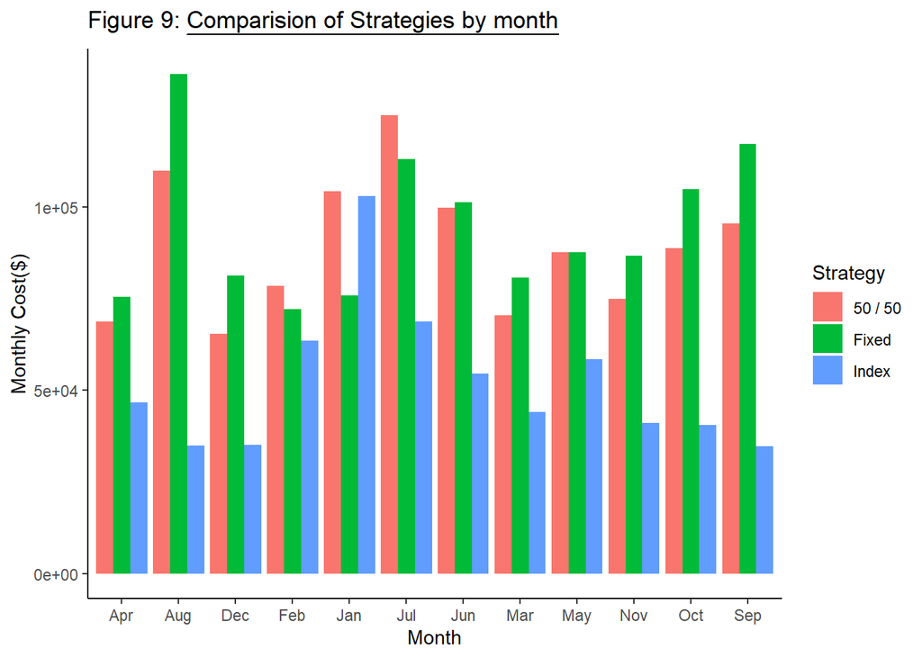